# R Notebook

### Introduction

This notebook will help you understand the behaviour of Hotstar users in the given data set. Using, simple bar plots you will understand how the target variable (segment) fairs against given features.

Along with exploration, you will learn how to work with lists in R, which I believe is quite tricky! To dive deep, check starter scripts.

### Load Libraries and Data set

```r
library(data.table)
library(jsonlite)
library(ggplot2)

train <- fromJSON("train_data.json")

train_data <- data.table(ID = unlist(names(train)))
train_data[, `:=` (genres = unlist(lapply(train, '[',1)),
                   titles = unlist(lapply(train, '[',2)),
                   cities = unlist(lapply(train, '[', 3)),
                   segment = unlist(lapply(train, '[',4)),
                   dow = unlist(lapply(train, '[',5)),
                   tod = unlist(lapply(train, '[', 6))
)]

test <- fromJSON("test_data.json")

test_data <- data.table(ID  = unlist(names(test)))
test_data[,`:=` (genres = unlist(lapply(test, '[',1)),
                 titles = unlist(lapply(test, '[',2)),
                 tod = unlist(lapply(test, '[', 3)),
                 cities = unlist(lapply(test, '[',4)),
                 dow = unlist(lapply(test, '[',5))
)]


rm(train,test)
```

### Exploring Data

[output not shown]

```r
## Encode Target Variable
train_data[, segment := ifelse(segment == 'neg',0,1)]
train_data[,.N/nrow(train_data), segment]
```

[output not shown]

From the table above, we learn that the target variable is imbalanced.

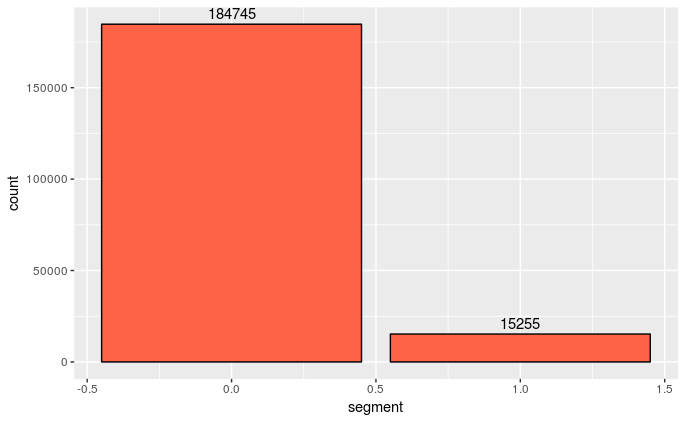

Lets see which genres are the most popular among hotstar users.

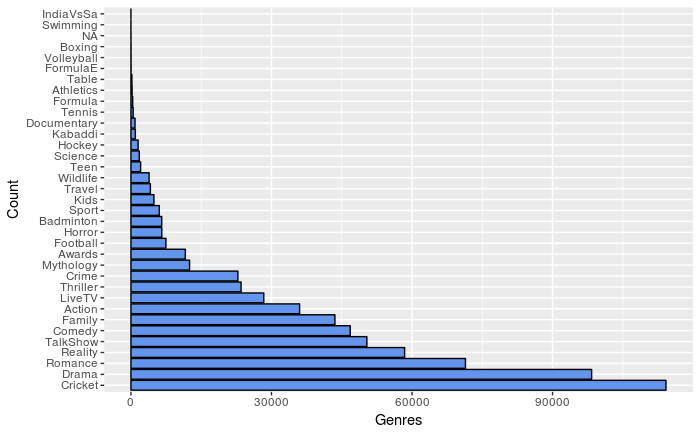

There are 35 unique genres in the data set. Looks like hotstar has maximum video content on Cricket or we can say hotstar users watch cricket a lot, which is followed by Drama, Romance, Reality. Based on watch behaviour, I think we can safely assume that mode segment of hotstar users is relatively young i.e. 16-25 years It will be better if we confirm our hypothesis. Let’s check the mean segment value by genres. This will help us understand the behaviour of users belonging to pos, neg class.

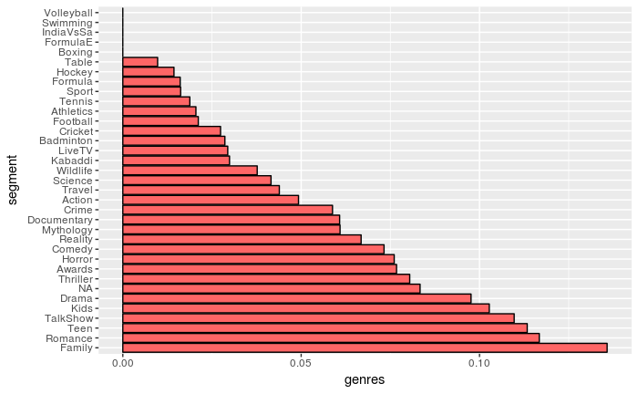

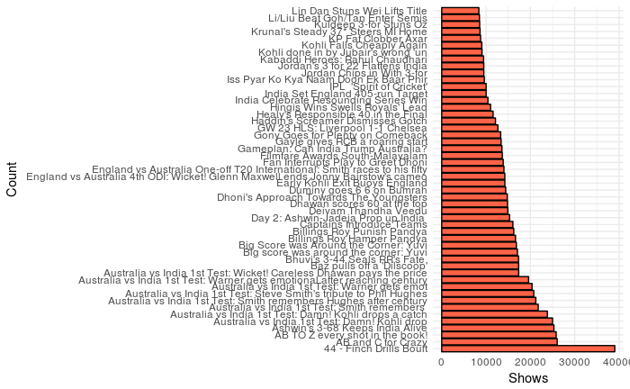

Now, let’s see from which city does hotstar viewers come!

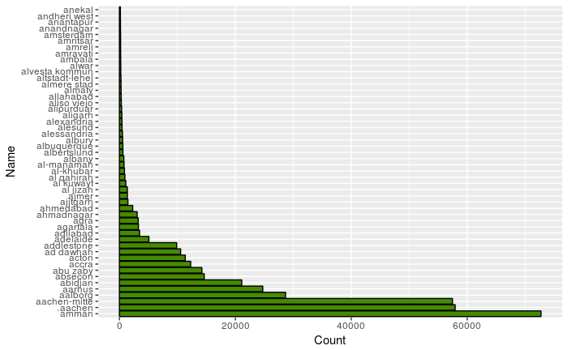

Based on statistics above about hotstar users i.e. they are cricket addicts. The cities have a different story to tell. Maximum users come from amman (city in Jordon), followed by aachen (city in Germany), then a city from Denmark, Ivory Coast, US etc. Surprising to see, cities like Agra and Agartala appearing on this list. I was expecting users from indian citiesto dominate this video hosting website. Looks like, it’s one of the favorite destination of indians living abroad.

Let’s proceed and understand on which days do these users come to watch videos.

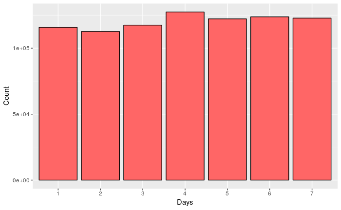

Not much variation in week days. May be hours will be more interesting to look at.

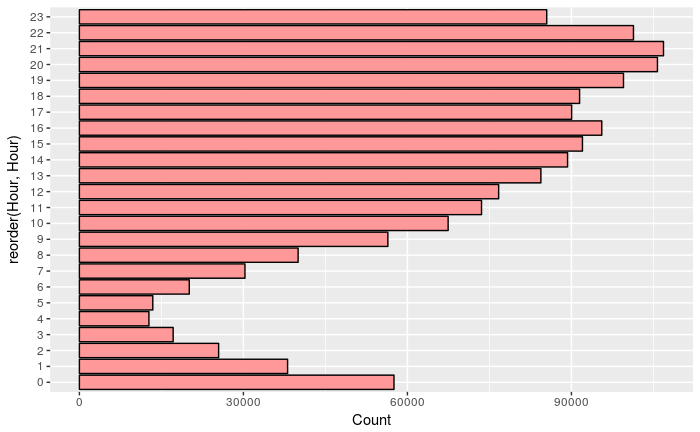

Nothing surprising according to the nature of indians. Peak occurs at 9pm and start declining as night dawns. Let’s check the mean of target variable by hour.

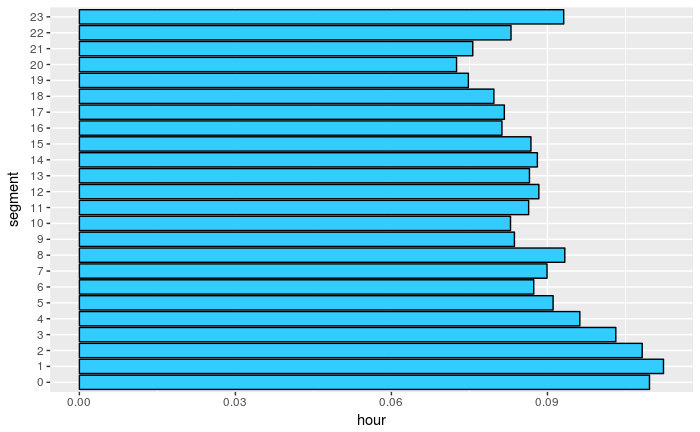

Let’s see!

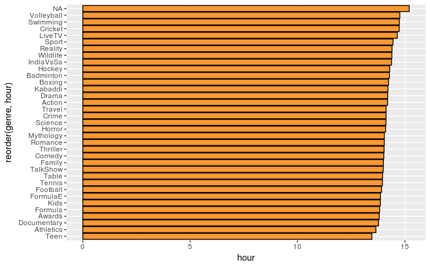

## Summary

This notebook is created to help you understand the nature of this data set. Since is data isn’t as structured as you would expect, this exploration notebook might provide you useful ideas to create new features. Good luck for the competition!